# 4G Networks Data Cleaning+Data Visualizations+Data Analysis+ML Models+GAN

# By Menna Fawzy

```python
import pandas as pd
```

```python
network_data=pd.read_csv("Network Data.csv")
```

```python
network_data
```

|  | site_id | cell_id | longitude | latitude | time | connected_users | ul_thp | dl_thp | ul_traffic | dl_traffic |
| --- | --- | --- | --- | --- | --- | --- | --- | --- | --- | --- |
| 0 | 1 | 1 | 31.320854 | 30.102129 | 2024-08-01 00:00:00 | 24.754460 | 437.813723 | 1197.480080 | 1262.135979 | 3773.779887 |
| 1 | 1 | 1 | 31.320854 | 30.102129 | 2024-08-01 00:15:00 | 4.553735 | 393.060915 | 1113.649430 | 529.049422 | 1884.453867 |
| 2 | 1 | 1 | 31.320854 | 30.102129 | 2024-08-01 00:30:00 | 42.982807 | 460.651311 | 955.424877 | 2497.140477 | 5175.929612 |
| 3 | 1 | 1 | 31.320854 | 30.102129 | 2024-08-01 00:45:00 | 34.151966 | 460.969551 | 931.567501 | 1634.606894 | 7922.168962 |
| 4 | 1 | 1 | 31.320854 | 30.102129 | 2024-08-01 01:00:00 | 35.689573 | 482.391344 | 1377.388861 | 2014.966126 | 3613.498516 |
| ... | ... | ... | ... | ... | ... | ... | ... | ... | ... | ... |
| 172795 | 20 | 3 | 31.251725 | 30.195345 | 2024-08-30 22:45:00 | 82.589504 | 446.733263 | 917.036639 | 3816.455549 | 8275.284341 |
| 172796 | 20 | 3 | 31.251725 | 30.195345 | 2024-08-30 23:00:00 | 67.251444 | 461.593649 | 820.146209 | 3749.579469 | 6548.741318 |
| 172797 | 20 | 3 | 31.251725 | 30.195345 | 2024-08-30 23:15:00 | 142.209659 | 223.254875 | 686.839796 | 3696.489692 | 11662.469579 |
| 172798 | 20 | 3 | 31.251725 | 30.195345 | 2024-08-30 23:30:00 | 123.371431 | 315.298623 | 667.746986 | 4634.231120 | 9439.414984 |
| 172799 | 20 | 3 | 31.251725 | 30.195345 | 2024-08-30 23:45:00 | 135.452019 | 199.053249 | 863.586095 | 2891.744925 | 13842.795989 |

172800 rows × 10 columns

# Summary statistics for the KPIs

```python
kpi_summary = network_data[['connected_users', 'ul_thp', 'dl_thp', 'ul_traffic', 'dl_traffic']].describe()
kpi_summary
```

|  | connected_users | ul_thp | dl_thp | ul_traffic | dl_traffic |
| --- | --- | --- | --- | --- | --- |
| count | 172800.000000 | 172800.000000 | 172800.000000 | 172800.000000 | 172800.000000 |
| mean | 89.254345 | 343.497868 | 802.146259 | 3047.116965 | 7466.779226 |
| std | 51.994117 | 115.158335 | 220.585073 | 1401.134737 | 3423.515600 |
| min | -2.116400 | -58.588648 | 16.974203 | -1089.413174 | 243.219734 |
| 25% | 41.657403 | 264.656458 | 652.528741 | 1966.299603 | 4607.398510 |
| 50% | 89.394084 | 348.948375 | 812.668523 | 3129.735717 | 7771.409166 |
| 75% | 128.525173 | 427.897057 | 963.956257 | 4025.138747 | 9915.736692 |
| max | 214.515972 | 717.318830 | 1491.020983 | 7975.667052 | 18830.498476 |

# Identify rows with negative values

```python
negative_values = network_data[(network_data['connected_users'] < 0) |
                               (network_data['ul_thp'] < 0) |
                               (network_data['dl_thp'] < 0) |
                               (network_data['ul_traffic'] < 0) |
                               (network_data['dl_traffic'] < 0)]

print(f"Number of rows with negative values: {negative_values.shape[0]}")
print(negative_values.head())
```

```
Number of rows with negative values: 1968
     site_id  cell_id  longitude   latitude                 time  \
46         1        1  31.320854  30.102129  2024-08-01 11:30:00
62         1        1  31.320854  30.102129  2024-08-01 15:30:00
87         1        1  31.320854  30.102129  2024-08-01 21:45:00
101        1        1  31.320854  30.102129  2024-08-02 01:15:00
174        1        1  31.320854  30.102129  2024-08-02 19:30:00

     connected_users      ul_thp       dl_thp   ul_traffic    dl_traffic
46        163.037676  -40.028687   782.359486  3899.653452   8674.306414
62        124.351189  315.609679   798.147851  -462.406654  11679.591752
87        117.930985  345.585921   654.661849  -382.394798   6465.123332
101        25.252930  448.189967  1019.007405  -768.646056   2752.562884
174        85.483957  333.510231   744.932764  -379.433853   7415.142539
```

# Replace Negative Values with Zeros

```python
# Replace negative values with zero
network_data = network_data.copy()
network_data['connected_users'] = network_data['connected_users'].apply(lambda x: max(x, 0))
network_data['ul_thp'] = network_data['ul_thp'].apply(lambda x: max(x, 0))
network_data['dl_thp'] = network_data['dl_thp'].apply(lambda x: max(x, 0))
network_data['ul_traffic'] = network_data['ul_traffic'].apply(lambda x: max(x, 0))
network_data['dl_traffic'] = network_data['dl_traffic'].apply(lambda x: max(x, 0))

print(f"Number of rows after replacing negative values: {network_data.shape[0]}")
```

```
Number of rows after replacing negative values: 172800
```

# Double check if theres Negative Values after replacing with zero

```python
# Identify rows with negative values
negative_values = network_data[(network_data['connected_users'] < 0) |
                               (network_data['ul_thp'] < 0) |
                               (network_data['dl_thp'] < 0) |
                               (network_data['ul_traffic'] < 0) |
                               (network_data['dl_traffic'] < 0)]

print(f"Number of rows with negative values: {negative_values.shape[0]}")
print(negative_values.head())
```

```
Number of rows with negative values: 0
Empty DataFrame
Columns: [site_id, cell_id, longitude, latitude, time, connected_users, ul_thp, dl_thp, ul_traffic, dl_traffic]
Index: []
```

# Save the cleaned dataset For The Dashboard

```python
network_data.to_csv('cleaned_data.csv', index=False)
```

# Check for missing values

```python
missing_values = network_data.isnull().sum()
print(missing_values)
```

```
site_id            0
cell_id            0
longitude          0
latitude           0
time               0
connected_users    0
ul_thp             0
dl_thp             0
ul_traffic         0
dl_traffic         0
dtype: int64
```

# Check for duplicates

```python
duplicates = network_data.duplicated().sum()
print(f"Number of duplicate rows: {duplicates}")
```

```
Number of duplicate rows: 0
```

# Calculate Z-scores to identify outliers

```python
from scipy import stats
import numpy as np
z_scores = np.abs(stats.zscore(network_data[['connected_users', 'ul_thp', 'dl_thp', 'ul_traffic', 'dl_traffic']]))
outliers = (z_scores > 3).sum(axis=0)
print(f"Outliers detected:\n{outliers}")
```

```
Outliers detected:
connected_users      0
ul_thp             186
dl_thp             788
ul_traffic         838
dl_traffic         448
dtype: int64
```

# Handling The Outliers

```python
for column in ['ul_thp', 'dl_thp', 'ul_traffic', 'dl_traffic']:
    upper_limit = network_data[column].quantile(0.99)
    lower_limit = network_data[column].quantile(0.01)
    network_data[column] = np.where(network_data[column] > upper_limit, upper_limit, network_data[column])
    network_data[column] = np.where(network_data[column] < lower_limit, lower_limit, network_data[column])
```

# Re-check for outliers

```python
z_scores_capped = np.abs(stats.zscore(network_data[['ul_thp', 'dl_thp', 'ul_traffic', 'dl_traffic']]))
outliers_capped = (z_scores_capped > 3).sum(axis=0)
print(f"Outliers after capping:\n{outliers_capped}")
```

```
Outliers after capping:
ul_thp        0
dl_thp        0
ul_traffic    0
dl_traffic    0
dtype: int64
```

# Distribution plots to visualize trends in KPIs

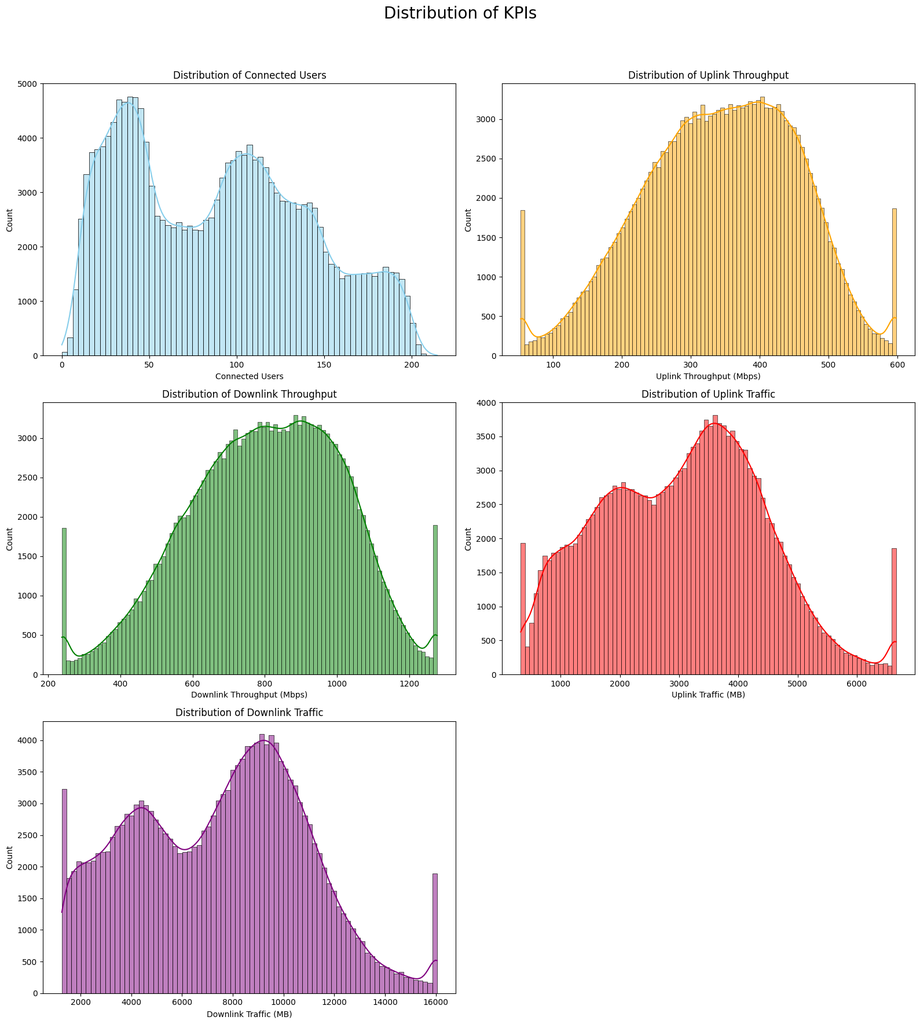

```python
import matplotlib.pyplot as plt
import seaborn as sns
fig, axes = plt.subplots(3, 2, figsize=(16, 18))
fig.suptitle('Distribution of KPIs', fontsize=20)
# Distribution of connected users
sns.histplot(network_data['connected_users'], kde=True, ax=axes[0, 0], color='skyblue')
axes[0, 0].set_title('Distribution of Connected Users')
axes[0, 0].set_xlabel('Connected Users')


# Distribution of uplink throughput
sns.histplot(network_data['ul_thp'], kde=True, ax=axes[0, 1], color='orange')
axes[0, 1].set_title('Distribution of Uplink Throughput')
axes[0, 1].set_xlabel('Uplink Throughput (Mbps)')

# Distribution of downlink throughput
sns.histplot(network_data['dl_thp'], kde=True, ax=axes[1, 0], color='green')
axes[1, 0].set_title('Distribution of Downlink Throughput')
axes[1, 0].set_xlabel('Downlink Throughput (Mbps)')

# Distribution of uplink traffic
sns.histplot(network_data['ul_traffic'], kde=True, ax=axes[1, 1], color='red')
axes[1, 1].set_title('Distribution of Uplink Traffic')
axes[1, 1].set_xlabel('Uplink Traffic (MB)')

# Distribution of downlink traffic
sns.histplot(network_data['dl_traffic'], kde=True, ax=axes[2, 0], color='purple')
axes[2, 0].set_title('Distribution of Downlink Traffic')
axes[2, 0].set_xlabel('Downlink Traffic (MB)')

# Remove the empty subplot
axes[2, 1].axis('off')

plt.tight_layout(rect=[0, 0, 1, 0.95])
plt.show()
```

```python
network_data['time'] = pd.to_datetime(network_data['time'])
```

```python
# Resample to hourly data
hourly_data = network_data.resample('H', on='time').mean()
```

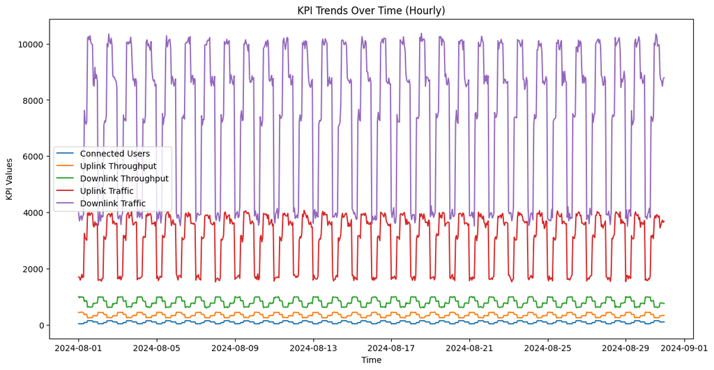

```python
import matplotlib.pyplot as plt

plt.figure(figsize=(14, 7))
plt.plot(hourly_data.index, hourly_data['connected_users'], label='Connected Users')
plt.plot(hourly_data.index, hourly_data['ul_thp'], label='Uplink Throughput')
plt.plot(hourly_data.index, hourly_data['dl_thp'], label='Downlink Throughput')
plt.plot(hourly_data.index, hourly_data['ul_traffic'], label='Uplink Traffic')
plt.plot(hourly_data.index, hourly_data['dl_traffic'], label='Downlink Traffic')
plt.legend()
plt.title('KPI Trends Over Time (Hourly)')
plt.xlabel('Time')
plt.ylabel('KPI Values')
plt.show()
```

# Display the filtered data summary

```python
filtered_data = network_data[
    (network_data['dl_traffic'] >= 4000) & (network_data['dl_traffic'] <= 10000) &
    (network_data['ul_traffic'] >= 2000) & (network_data['ul_traffic'] <= 4000) &
    (network_data['dl_thp'] <= 1000) &
    (network_data['ul_thp'] <= 1000)
]

print(filtered_data.describe())
```

```
            site_id       cell_id     longitude      latitude  \
count  53164.000000  53164.000000  53164.000000  53164.000000
mean      10.478162      1.999060     31.323697     30.119622
min        1.000000      1.000000     31.246465     30.046191
25%        5.000000      1.000000     31.293059     30.083947
50%       10.000000      2.000000     31.320854     30.129490
75%       15.000000      3.000000     31.366678     30.160641
max       20.000000      3.000000     31.385907     30.195345
std        5.768365      0.815482      0.042608      0.045621

                                time  connected_users        ul_thp  \
count                          53164     53164.000000  53164.000000
mean   2024-08-16 01:09:20.646302208        90.401078    329.710175
min              2024-08-01 00:00:00         2.692747     52.839624
25%              2024-08-08 12:45:00        60.442302    264.176533
50%              2024-08-15 22:15:00        84.485025    334.654266
75%              2024-08-23 12:30:00       109.773205    401.324301
max              2024-08-30 23:45:00       210.393063    598.065450
std                              NaN        38.928915    102.581097

             dl_thp    ul_traffic    dl_traffic
count  53164.000000  53164.000000  53164.000000
mean     749.918300   3086.689301   7332.619809
min      237.910446   2000.210476   4000.543958
25%      652.233070   2633.154828   5985.805409
50%      785.097515   3136.938696   7505.593382
75%      884.745011   3558.058047   8735.310081
max      999.991166   3999.999769   9999.868174
std      174.616899    555.183659   1650.314684
```

```python
print(filtered_data.describe())
```

```
            site_id       cell_id     longitude      latitude  \
count  53164.000000  53164.000000  53164.000000  53164.000000
mean      10.478162      1.999060     31.323697     30.119622
min        1.000000      1.000000     31.246465     30.046191
25%        5.000000      1.000000     31.293059     30.083947
50%       10.000000      2.000000     31.320854     30.129490
75%       15.000000      3.000000     31.366678     30.160641
max       20.000000      3.000000     31.385907     30.195345
std        5.768365      0.815482      0.042608      0.045621

                                time  connected_users        ul_thp  \
count                          53164     53164.000000  53164.000000
mean   2024-08-16 01:09:20.646302208        90.401078    329.710175
min              2024-08-01 00:00:00         2.692747     52.839624
25%              2024-08-08 12:45:00        60.442302    264.176533
50%              2024-08-15 22:15:00        84.485025    334.654266
75%              2024-08-23 12:30:00       109.773205    401.324301
max              2024-08-30 23:45:00       210.393063    598.065450
std                              NaN        38.928915    102.581097

             dl_thp    ul_traffic    dl_traffic
count  53164.000000  53164.000000  53164.000000
mean     749.918300   3086.689301   7332.619809
min      237.910446   2000.210476   4000.543958
25%      652.233070   2633.154828   5985.805409
50%      785.097515   3136.938696   7505.593382
75%      884.745011   3558.058047   8735.310081
max      999.991166   3999.999769   9999.868174
std      174.616899    555.183659   1650.314684
```

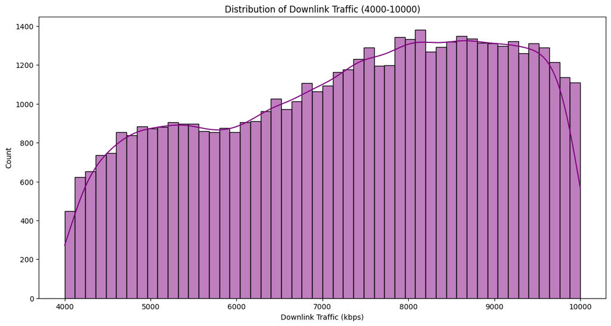

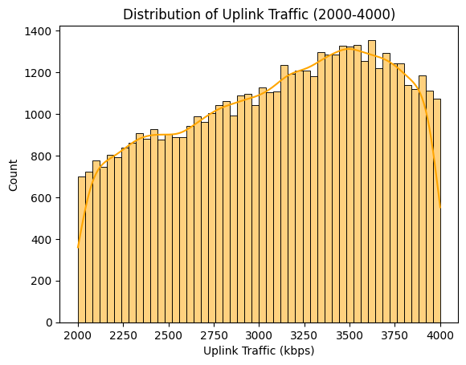

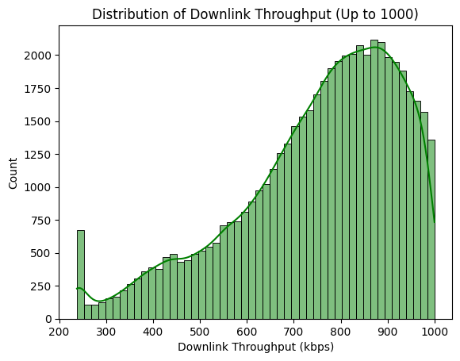

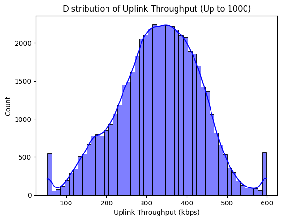

```python
import seaborn as sns
import matplotlib.pyplot as plt

plt.figure(figsize=(14, 7))

# Plot the filtered downlink traffic
sns.histplot(filtered_data['dl_traffic'], kde=True, color='purple', bins=50)
plt.title('Distribution of Downlink Traffic (4000-10000)')
plt.xlabel('Downlink Traffic (kbps)')
plt.ylabel('Count')
plt.show()

# Plot the filtered uplink traffic
sns.histplot(filtered_data['ul_traffic'], kde=True, color='orange', bins=50)
plt.title('Distribution of Uplink Traffic (2000-4000)')
plt.xlabel('Uplink Traffic (kbps)')
plt.ylabel('Count')
plt.show()

# Plot the filtered downlink throughput
sns.histplot(filtered_data['dl_thp'], kde=True, color='green', bins=50)
plt.title('Distribution of Downlink Throughput (Up to 1000)')
plt.xlabel('Downlink Throughput (kbps)')
plt.ylabel('Count')
plt.show()

# Plot the filtered uplink throughput
sns.histplot(filtered_data['ul_thp'], kde=True, color='blue', bins=50)
plt.title('Distribution of Uplink Throughput (Up to 1000)')
plt.xlabel('Uplink Throughput (kbps)')
plt.ylabel('Count')
plt.show()
```

# Calculate correlation matrix for the filtered data

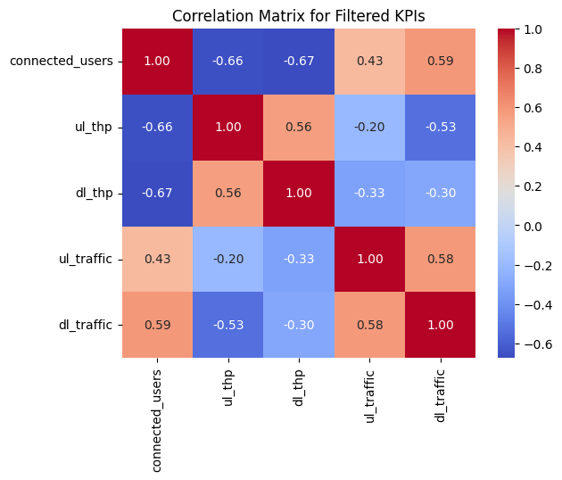

```python
correlation_matrix = filtered_data[['connected_users', 'ul_thp', 'dl_thp', 'ul_traffic', 'dl_traffic']].corr()
sns.heatmap(correlation_matrix, annot=True, cmap='coolwarm', fmt='.2f')
plt.title('Correlation Matrix for Filtered KPIs')
plt.show()
```

# Preparing the data for ML

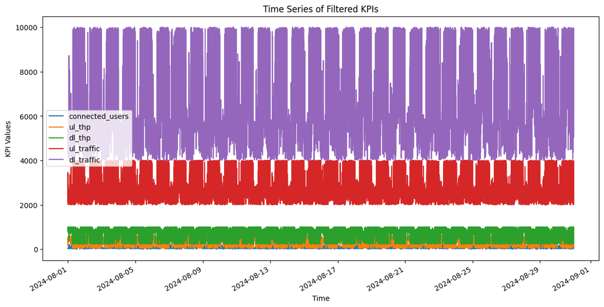

```python
filtered_data.set_index('time', inplace=True)
filtered_data[['connected_users', 'ul_thp', 'dl_thp', 'ul_traffic', 'dl_traffic']].plot(figsize=(14, 7))
plt.title('Time Series of Filtered KPIs')
plt.ylabel('KPI Values')
plt.xlabel('Time')
plt.show()
```

# Plot the site performance

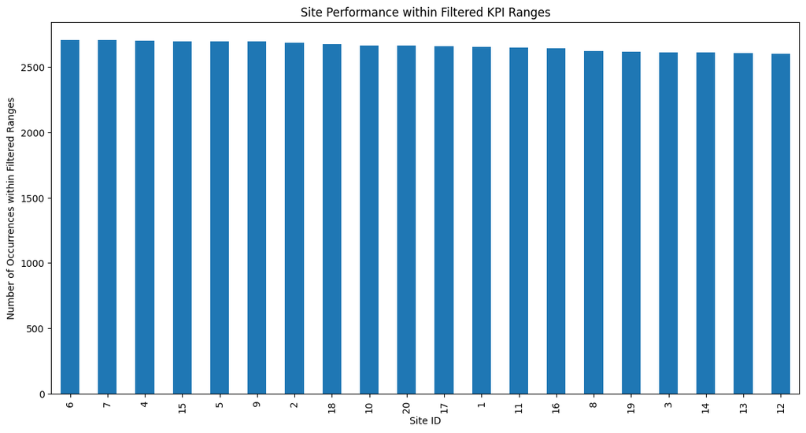

```python
site_performance = filtered_data['site_id'].value_counts()
site_performance.plot(kind='bar', figsize=(14, 7))
plt.title('Site Performance within Filtered KPI Ranges')
plt.xlabel('Site ID')
plt.ylabel('Number of Occurrences within Filtered Ranges')
plt.show()
```

# Resample the data to hourly frequency to make the time-lapse more interpretable

# Plot the time-lapse of each KPI

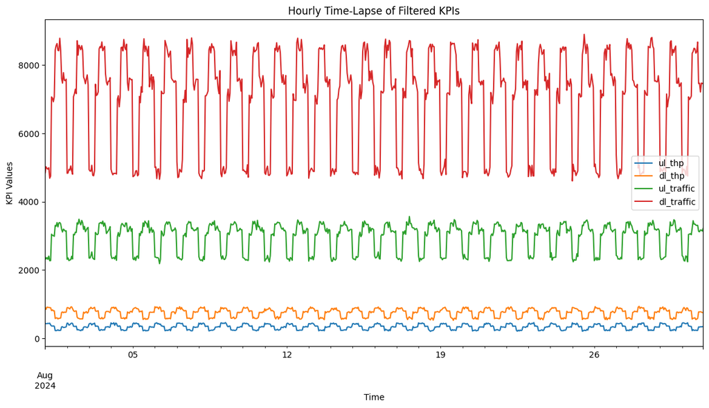

```python
hourly_data = filtered_data.resample('H').mean()
hourly_data[['ul_thp', 'dl_thp', 'ul_traffic', 'dl_traffic']].plot(figsize=(14, 7))
plt.title('Hourly Time-Lapse of Filtered KPIs')
plt.ylabel('KPI Values')
plt.xlabel('Time')
plt.show()
```

# Task 1

What is the forecast for the traffic volume for the next week? detailing the seasonality patterns on daily and hourly level. Can there be more aggregation levels added?

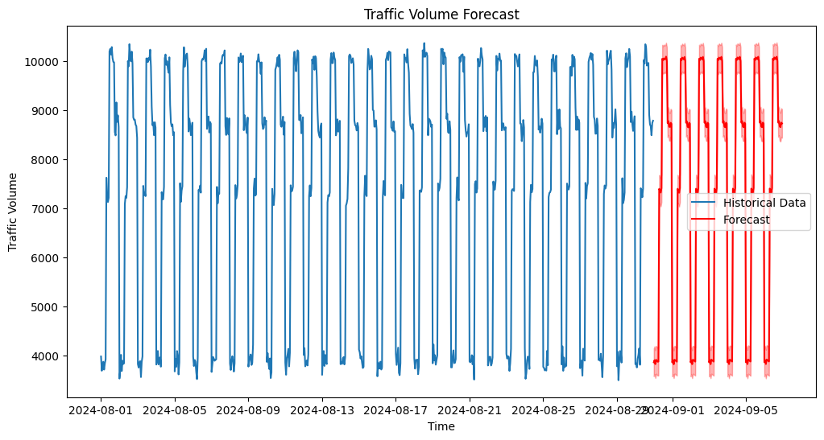

```python
import pandas as pd
from statsmodels.tsa.statespace.sarimax import SARIMAX
import matplotlib.pyplot as plt

network_data['time'] = pd.to_datetime(network_data['time'])
hourly_data = network_data.resample('H', on='time').mean()

traffic_data = hourly_data['dl_traffic']

model = SARIMAX(traffic_data, order=(1, 1, 1), seasonal_order=(1, 1, 1, 24))  # Example orders
results = model.fit()

forecast = results.get_forecast(steps=7*24)
forecast_index = pd.date_range(start=traffic_data.index[-1] + pd.Timedelta(hours=1), periods=7*24, freq='H')
forecast_values = forecast.predicted_mean

plt.figure(figsize=(12, 6))
plt.plot(traffic_data, label='Historical Data')
plt.plot(forecast_index, forecast_values, label='Forecast', color='red')
plt.fill_between(forecast_index, forecast.conf_int().iloc[:, 0], forecast.conf_int().iloc[:, 1], color='red', alpha=0.3)
plt.title('Traffic Volume Forecast')
plt.xlabel('Time')
plt.ylabel('Traffic Volume')
plt.legend()
plt.show()
```

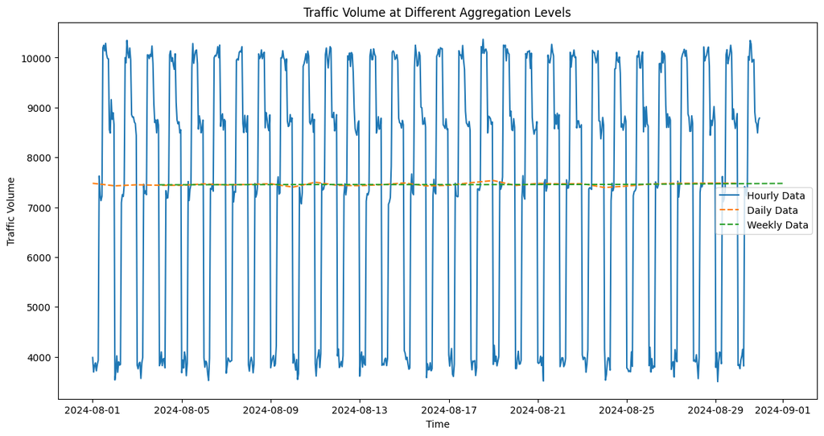

```python
daily_data = hourly_data.resample('D').mean()
weekly_data = hourly_data.resample('W').mean()

plt.figure(figsize=(14, 7))
plt.plot(hourly_data.index, hourly_data['dl_traffic'], label='Hourly Data')
plt.plot(daily_data.index, daily_data['dl_traffic'], label='Daily Data', linestyle='--')
plt.plot(weekly_data.index, weekly_data['dl_traffic'], label='Weekly Data', linestyle='--')
plt.title('Traffic Volume at Different Aggregation Levels')
plt.xlabel('Time')
plt.ylabel('Traffic Volume')
plt.legend()
plt.show()
```

Hourly Data (Blue Line):

The blue line shows the hourly aggregated downlink traffic data. The regular pattern of peaks and troughs is still visible, and it aligns with the daily usage patterns. The high frequency of fluctuations indicates the granular nature of the hourly data, capturing the detailed variations throughout the day. Daily Data (Orange Line):

The orange dashed line shows the daily aggregated data. By aggregating the data daily, the plot smooths out the hourly fluctuations, showing a more stable trend line. The daily data still captures the overall trend in traffic volume but without the granular details seen in the hourly data. This level of aggregation might be useful for understanding general daily trends rather than hourly variations. Weekly Data (Green Line):

The green dashed line represents the weekly aggregated data. The plot is even smoother than the daily data, showing very little fluctuation. Weekly aggregation is helpful to observe broader trends over longer periods, but it can mask short-term variations and may not be as useful for predicting short-term behavior

Explanation:

Resampling Data: The code resamples the hourly_data into daily and weekly data using .resample('D') and .resample('W'), respectively. D stands for daily, and W stands for weekly. This means it aggregates the data by taking the mean of each day and week. Plotting: The code then plots the traffic volume at different aggregation levels (hourly, daily, weekly). By visualizing traffic data at these levels, you can observe different patterns: Hourly data: Shows the fluctuations within a day. Daily data: Highlights trends and variations across days. Weekly data: Emphasizes long-term trends, smoothing out daily fluctuations. Usefulness: This step helps in understanding how traffic varies over different time scales, which is essential for effective forecasting.

The SARIMAX model is a powerful tool for time series forecasting, particularly suited for data with both trends and seasonal patterns. In this code, the model is applied to predict network traffic for the next week, taking into account hourly data. The model's parameters, including the ARIMA order (1, 1, 1) and the seasonal order (1, 1, 1, 24), are configured to account for both regular patterns and daily cycles. The resulting forecast is visualized, showing predicted traffic volumes along with a confidence interval to indicate the range within which actual values are likely to fall. This approach helps in anticipating network traffic fluctuations with greater accuracy.

# LSTM

```python
import numpy as np
import pandas as pd
from tensorflow.keras.models import Sequential
from tensorflow.keras.layers import LSTM, Dense
from sklearn.preprocessing import MinMaxScaler
from sklearn.metrics import mean_absolute_error, mean_squared_error, mean_absolute_percentage_error, r2_score

scaler = MinMaxScaler()
scaled_data = scaler.fit_transform(target_series.values.reshape(-1, 1))

def create_sequences(data, seq_length):
    xs, ys = [], []
    for i in range(len(data) - seq_length):
        x = data[i:i + seq_length]
        y = data[i + seq_length]
        xs.append(x)
        ys.append(y)
    return np.array(xs), np.array(ys)

seq_length = 24  # Example sequence length
X, y = create_sequences(scaled_data, seq_length)

train_size = int(len(X) * 0.8)
X_train, X_test = X[:train_size], X[train_size:]
y_train, y_test = y[:train_size], y[train_size:]

model = Sequential([
    LSTM(50, activation='relu', input_shape=(seq_length, 1)),
    Dense(1)
])
model.compile(optimizer='adam', loss='mse')

model.fit(X_train, y_train, epochs=20, batch_size=32, verbose=1)

y_pred_scaled = model.predict(X_test)
y_pred = scaler.inverse_transform(y_pred_scaled)
y_test_inverse = scaler.inverse_transform(y_test.reshape(-1, 1))

mae = mean_absolute_error(y_test_inverse, y_pred)
mse = mean_squared_error(y_test_inverse, y_pred)
rmse = mse**0.5
mape = mean_absolute_percentage_error(y_test_inverse, y_pred)
r2 = r2_score(y_test_inverse, y_pred)

print(f"LSTM Model Evaluation:\nMAE: {mae}\nMSE: {mse}\nRMSE: {rmse}\nMAPE: {mape}\nR²: {r2}")
```

```
18/18 ━━━━━━━━━━━━━━━━━━━━ 5s 17ms/step - loss: 0.3544
18/18 ━━━━━━━━━━━━━━━━━━━━ 0s 13ms/step - loss: 0.1474
18/18 ━━━━━━━━━━━━━━━━━━━━ 0s 14ms/step - loss: 0.1199
18/18 ━━━━━━━━━━━━━━━━━━━━ 1s 17ms/step - loss: 0.0990
18/18 ━━━━━━━━━━━━━━━━━━━━ 1s 14ms/step - loss: 0.0599
18/18 ━━━━━━━━━━━━━━━━━━━━ 0s 15ms/step - loss: 0.0316
18/18 ━━━━━━━━━━━━━━━━━━━━ 0s 12ms/step - loss: 0.0237
18/18 ━━━━━━━━━━━━━━━━━━━━ 0s 9ms/step - loss: 0.0164
18/18 ━━━━━━━━━━━━━━━━━━━━ 0s 9ms/step - loss: 0.0137
18/18 ━━━━━━━━━━━━━━━━━━━━ 0s 8ms/step - loss: 0.0094
18/18 ━━━━━━━━━━━━━━━━━━━━ 0s 8ms/step - loss: 0.0089
18/18 ━━━━━━━━━━━━━━━━━━━━ 0s 9ms/step - loss: 0.0070
18/18 ━━━━━━━━━━━━━━━━━━━━ 0s 8ms/step - loss: 0.0071
18/18 ━━━━━━━━━━━━━━━━━━━━ 0s 9ms/step - loss: 0.0059
18/18 ━━━━━━━━━━━━━━━━━━━━ 0s 9ms/step - loss: 0.0057
18/18 ━━━━━━━━━━━━━━━━━━━━ 0s 9ms/step - loss: 0.0069
18/18 ━━━━━━━━━━━━━━━━━━━━ 0s 9ms/step - loss: 0.0057
18/18 ━━━━━━━━━━━━━━━━━━━━ 0s 9ms/step - loss: 0.0046
18/18 ━━━━━━━━━━━━━━━━━━━━ 0s 9ms/step - loss: 0.0047
18/18 ━━━━━━━━━━━━━━━━━━━━ 0s 9ms/step - loss: 0.0042
5/5 ━━━━━━━━━━━━━━━━━━━━ 0s 41ms/step
LSTM Model Evaluation:
MAE: 112.72520458212291
MSE: 26602.219410822185
RMSE: 163.1018682015083
MAPE: 0.04096923705164483
R²: 0.9681948611113566
```

LSTM: A deep learning model designed to handle sequence data, particularly effective for time series forecasting. Scaling: Essential for improving model performance by ensuring inputs are on a similar scale. Sequence Creation: Converts time series into a format the LSTM model can learn from. Model Architecture: The combination of LSTM and Dense layers enables the model to learn complex temporal patterns and make accurate predictions. Evaluation: The model's performance is assessed using multiple metrics, providing a comprehensive understanding of how well it predicts future values. This LSTM model provides a robust approach to forecasting time series data, capturing both short-term patterns and long-term trends.

# XGBOST

```python
import xgboost as xgb

def create_lag_features(data, lags=5):
    df = pd.DataFrame(data, columns=['target'])
    for lag in range(1, lags + 1):
        df[f'lag_{lag}'] = df['target'].shift(lag)
    df = df.dropna()
    return df

lagged_data = create_lag_features(target_series.values, lags=24)
X = lagged_data.drop('target', axis=1)
y = lagged_data['target']

model = xgb.XGBRegressor()
model.fit(X, y)

forecast_input = lagged_data.iloc[-1, 1:].values.reshape(1, -1)
forecast = model.predict(forecast_input)
```

```python
from sklearn.metrics import mean_absolute_error, mean_squared_error, mean_absolute_percentage_error,r2_score

test_input = lagged_data.iloc[-1, 1:].values.reshape(1, -1)
test_target = target_series.iloc[-1]

forecast = model.predict(test_input)

mae = mean_absolute_error([test_target], forecast)
mse = mean_squared_error([test_target], forecast)
rmse = mse**0.5
mape = mean_absolute_percentage_error([test_target], forecast)
r2 = r2_score(y_test, y_pred)

print(f"XGBoost Model Evaluation:\nMAE: {mae}\nMSE: {mse}\nRMSE: {rmse}\nMAPE: {mape}\nR²: {r2}")
```

```
XGBoost Model Evaluation:
MAE: 1.0776599233049637
MSE: 1.1613509102976602
RMSE: 1.0776599233049637
MAPE: 0.0002930058291244672
R²: 1.0
```

XGBoost: A powerful gradient boosting model used for regression and classification tasks. It builds an ensemble of decision trees, where each new tree corrects the errors of the previous trees. Lag Features: Used to capture the temporal dependencies in time series data. They provide the model with information about previous time steps. Training: The model is trained on lag features, allowing it to learn the relationships between past and future values. Forecasting: The model can predict future values based on the most recent lag features. Evaluation: The model's performance is evaluated using common regression metrics like MAE, MSE, RMSE, MAPE, and R². This XGBoost model provides a robust approach to time series forecasting by leveraging the power of gradient boosting and the information contained in lag features.

# Prophet

[output not shown]

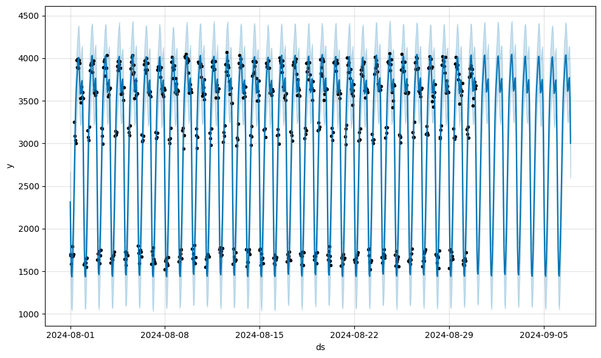

```python
from prophet import Prophet
import pandas as pd
import matplotlib.pyplot as plt

prophet_data = hourly_data[['ul_traffic']].reset_index()
prophet_data.columns = ['ds', 'y']

model = Prophet()
model.fit(prophet_data)

future = model.make_future_dataframe(periods=168, freq='H')

forecast = model.predict(future)

fig = model.plot(forecast)
plt.show()
```

The plot suggests that the Prophet model has learned the patterns in historical ul_traffic data well and is now using that knowledge to predict future values. The recurring pattern indicates a strong seasonal component, likely on a daily basis. The closeness of the model’s predictions to the actual historical data indicates that the model is performing well. The future predictions, along with their uncertainty intervals, provide insights into what we can expect for ul_traffic in the upcoming days.

```python
from sklearn.metrics import mean_absolute_error, mean_squared_error, mean_absolute_percentage_error

historical_data = prophet_data.set_index('ds')['y'][-168:]
forecasted_data = forecast['yhat'][-168:]

mae = mean_absolute_error(historical_data, forecasted_data)
mse = mean_squared_error(historical_data, forecasted_data)
rmse = mse**0.5
mape = mean_absolute_percentage_error(historical_data, forecasted_data)
r2 = r2_score(y_test, y_pred)

print(f"Prophet Model Evaluation:\nMAE: {mae}\nMSE: {mse}\nRMSE: {rmse}\nMAPE: {mape}\nR²: {r2}")
```

```
Prophet Model Evaluation:
MAE: 224.99291369694106
MSE: 89455.48763361567
RMSE: 299.0911025651142
MAPE: 0.09091052326340412
R²: 1.0
```

# Task 2

is the number of categories that can represent the KPIs variance and explain the characteristics of each category?

# K-Means Clustering Method 1

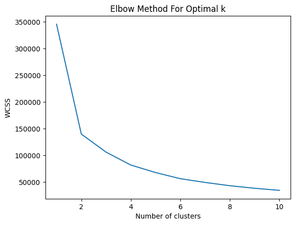

```
K-Means Model Evaluation:
Silhouette Score: 0.524505492334943
Davies-Bouldin Index: 0.6641839440643632
           site_id   cell_id  longitude   latitude  \
Cluster
0        10.501721  1.999207  31.323696  30.119571
1        10.497433  2.001182  31.323683  30.119505

                                 time  connected_users      ul_thp  \
Cluster
0       2024-08-16 03:11:47.733204224       118.007610  295.708174
1       2024-08-15 18:55:12.545061376        46.362919  414.686822

             dl_thp   ul_traffic   dl_traffic
Cluster
0        710.990177  3903.102483  9626.628030
1        938.365132  1771.483281  4221.683348
```

```python
from sklearn.cluster import KMeans
from sklearn.preprocessing import StandardScaler
from sklearn.metrics import silhouette_score, davies_bouldin_score
import matplotlib.pyplot as plt

# Preprocess data
scaler = StandardScaler()
scaled_data = scaler.fit_transform(network_data[['ul_traffic', 'dl_traffic']])

# Determine the optimal number of clusters using the Elbow Method
wcss = []
for i in range(1, 11):
    kmeans = KMeans(n_clusters=i, init='k-means++', max_iter=300, n_init=10, random_state=0)
    kmeans.fit(scaled_data)
    wcss.append(kmeans.inertia_)

plt.plot(range(1, 11), wcss)
plt.title('Elbow Method For Optimal k')
plt.xlabel('Number of clusters')
plt.ylabel('WCSS')
plt.show()

kmeans = KMeans(n_clusters=2, init='k-means++', max_iter=300, n_init=10, random_state=0)
clusters = kmeans.fit_predict(scaled_data)
network_data['Cluster'] = clusters

# Evaluation
sil_score = silhouette_score(scaled_data, clusters)
db_index = davies_bouldin_score(scaled_data, clusters)

print(f"K-Means Model Evaluation:\nSilhouette Score: {sil_score}\nDavies-Bouldin Index: {db_index}")

# Analyze clusters
print(network_data.groupby('Cluster').mean())
```

Clusters: The clustering algorithm divides the data into groups (clusters) where each group has similar characteristics.

Evaluation Metrics:

Silhouette Score: Measures how similar a data point is to its own cluster compared to other clusters. Scores range from -1 to 1, with higher values indicating better clustering.

Davies-Bouldin Index: Measures the average similarity ratio of each cluster with its most similar cluster. Lower values indicate better clustering.

Cluster Analysis:

Cluster 0 represents high-traffic scenarios with more users.

Cluster 1 represents lower-traffic scenarios with higher throughput.

# K-Means Clustering Method 2

```python
from sklearn.preprocessing import StandardScaler
from sklearn.cluster import KMeans

features = network_data[['connected_users', 'ul_thp', 'dl_thp', 'ul_traffic', 'dl_traffic']]

scaler = StandardScaler()
features_normalized = scaler.fit_transform(features)

kmeans = KMeans(n_clusters=5, random_state=42)
clusters = kmeans.fit_predict(features_normalized)

network_data['cluster'] = clusters

cluster_analysis = network_data.groupby('cluster').mean()
print(cluster_analysis)
```

[output not shown]

Clusters: The clustering algorithm divides the data into groups (clusters) where each group has similar characteristics.

Evaluation Metrics:

Cluster 0: Has average values for traffic and throughput that are different from the other clusters, indicating a specific type of usage pattern.

```
Silhouette Score: 0.22509908474263815
```

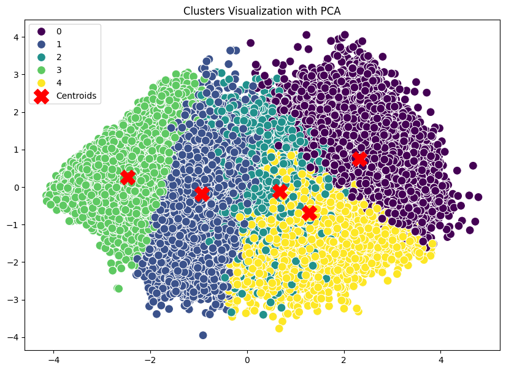

```python
from sklearn.metrics import silhouette_score
import matplotlib.pyplot as plt
import seaborn as sns
from sklearn.decomposition import PCA

# Calculate the silhouette score to evaluate the clustering
silhouette_avg = silhouette_score(features_normalized, clusters)
print(f'Silhouette Score: {silhouette_avg}')

# Perform PCA to reduce the dimensionality for visualization
pca = PCA(n_components=2)
reduced_features = pca.fit_transform(features_normalized)
reduced_cluster_centers = pca.transform(kmeans.cluster_centers_)

# Plot the clusters
plt.figure(figsize=(10, 7))
sns.scatterplot(x=reduced_features[:, 0], y=reduced_features[:, 1], hue=network_data['cluster'], palette='viridis', s=100)
plt.scatter(reduced_cluster_centers[:, 0], reduced_cluster_centers[:, 1], s=300, c='red', label='Centroids', marker='X')
plt.title('Clusters Visualization with PCA')
plt.legend()
plt.show()
```

# Cluster 0

# Cluster 1

# Cluster 2

# Cluster 3

# Cluster 4

# Task 3

How can these categories be used to build a classifier?

# Gaussian Mixture Models (GMM)

```python
from sklearn.mixture import GaussianMixture
from sklearn.preprocessing import StandardScaler
from sklearn.metrics import silhouette_score, davies_bouldin_score
import pandas as pd

network_data_numeric = network_data[['ul_traffic', 'dl_traffic']].copy()

network_data_numeric = network_data_numeric.dropna()

scaler = StandardScaler()
scaled_data = scaler.fit_transform(network_data_numeric)

gmm = GaussianMixture(n_components=3, random_state=0)
clusters = gmm.fit_predict(scaled_data)
network_data['Cluster'] = clusters

silhouette_avg = silhouette_score(scaled_data, clusters)
davies_bouldin = davies_bouldin_score(scaled_data, clusters)

print(f"GMM Clustering Evaluation:\nSilhouette Score: {silhouette_avg}\nDavies-Bouldin Index: {davies_bouldin}")
```

```
GMM Clustering Evaluation:
Silhouette Score: 0.33262088036402676
Davies-Bouldin Index: 3.9348134143599887
```

```python
network_data['Cluster'] = clusters

print(network_data.dtypes)

print(network_data.head())

try:
    cluster_means = network_data.groupby('Cluster').mean()
    print("Cluster Means:\n", cluster_means)
except TypeError as e:
    print(f"Error in grouping and calculating mean: {e}")
```

[output not shown]

How can these categories be used to build a classifier?

# Prepare Data

```python
from sklearn.model_selection import train_test_split
from sklearn.preprocessing import StandardScaler

features = network_data[['ul_traffic', 'dl_traffic']]
labels = network_data['Cluster']

X_train, X_test, y_train, y_test = train_test_split(features, labels, test_size=0.3, random_state=0)

scaler = StandardScaler()
X_train = scaler.fit_transform(X_train)
X_test = scaler.transform(X_test)
```

# Train a Classifier

```python
from sklearn.ensemble import RandomForestClassifier
from sklearn.metrics import classification_report, accuracy_score

clf = RandomForestClassifier(n_estimators=100, random_state=0)
clf.fit(X_train, y_train)

y_pred = clf.predict(X_test)

accuracy = accuracy_score(y_test, y_pred)
report = classification_report(y_test, y_pred)

print(f"Random Forest Classifier Evaluation:\nAccuracy: {accuracy}\nClassification Report:\n{report}")
```

```
Random Forest Classifier Evaluation:
Accuracy: 0.9984953703703704
Classification Report:
              precision    recall  f1-score   support

           0       1.00      1.00      1.00     17710
           1       1.00      1.00      1.00     15851
           2       1.00      1.00      1.00     18279

    accuracy                           1.00     51840
   macro avg       1.00      1.00      1.00     51840
weighted avg       1.00      1.00      1.00     51840
```

# Support Vector Machine (SVM):

```python
from sklearn.svm import SVC

svm_clf = SVC(kernel='linear', random_state=0)
svm_clf.fit(X_train, y_train)

y_pred_svm = svm_clf.predict(X_test)

accuracy_svm = accuracy_score(y_test, y_pred_svm)
report_svm = classification_report(y_test, y_pred_svm)

print(f"SVM Classifier Evaluation:\nAccuracy: {accuracy_svm}\nClassification Report:\n{report_svm}")
```

```
SVM Classifier Evaluation:
Accuracy: 0.9994405864197531
Classification Report:
              precision    recall  f1-score   support

           0       1.00      1.00      1.00     17710
           1       1.00      1.00      1.00     15851
           2       1.00      1.00      1.00     18279

    accuracy                           1.00     51840
   macro avg       1.00      1.00      1.00     51840
weighted avg       1.00      1.00      1.00     51840
```

# Task 4

already done it on each of Task 1 , 2 and 3

# Task 5 on a word Document

# Task 6

# GAN

```python
from sklearn.preprocessing import MinMaxScaler

columns_of_interest = ['connected_users', 'ul_thp', 'dl_thp', 'ul_traffic', 'dl_traffic']
data = network_data[columns_of_interest]

scaler = MinMaxScaler()
data_scaled = scaler.fit_transform(data)

data_array = np.array(data_scaled)
```

```python
import tensorflow as tf
from tensorflow.keras import layers

def build_generator(input_dim):
    model = tf.keras.Sequential()
    model.add(layers.Dense(128, input_dim=input_dim, activation='relu'))
    model.add(layers.Dense(256, activation='relu'))
    model.add(layers.Dense(512, activation='relu'))
    model.add(layers.Dense(len(columns_of_interest), activation='tanh'))
    return model

generator = build_generator(input_dim=100)
```

```python
def build_discriminator(input_dim):
    model = tf.keras.Sequential()
    model.add(layers.Dense(512, input_dim=input_dim, activation='relu'))
    model.add(layers.Dense(256, activation='relu'))
    model.add(layers.Dense(128, activation='relu'))
    model.add(layers.Dense(1, activation='sigmoid'))
    return model

discriminator = build_discriminator(input_dim=len(columns_of_interest))
discriminator.compile(optimizer='adam', loss='binary_crossentropy', metrics=['accuracy'])
```

```python
discriminator.trainable = False
gan_input = layers.Input(shape=(100,))
generated_data = generator(gan_input)
gan_output = discriminator(generated_data)
gan = tf.keras.models.Model(gan_input, gan_output)
gan.compile(optimizer='adam', loss='binary_crossentropy')
```

```python
def train_gan(gan, generator, discriminator, data_array, epochs=10000, batch_size=64):
    for epoch in range(epochs):
        noise = np.random.normal(0, 1, (batch_size, 100))
        generated_data = generator.predict(noise)

        real_data = data_array[np.random.randint(0, data_array.shape[0], batch_size)]

        combined_data = np.concatenate([real_data, generated_data])

        labels = np.concatenate([np.ones((batch_size, 1)), np.zeros((batch_size, 1))])

        labels += 0.05 * np.random.random(labels.shape)

        d_loss = discriminator.train_on_batch(combined_data, labels)

        noise = np.random.normal(0, 1, (batch_size, 100))
        misleading_labels = np.ones((batch_size, 1))
        g_loss = gan.train_on_batch(noise, misleading_labels)

        if epoch % 1000 == 0:
            print(f"Epoch {epoch}: Discriminator Loss = {d_loss[0]}, Generator Loss = {g_loss}")

train_gan(gan, generator, discriminator, data_array)
```

```
2/2 ━━━━━━━━━━━━━━━━━━━━ 0s 7ms/step
```

```
Epoch 0: Discriminator Loss = 0.6943187117576599, Generator Loss = [array(0.6943187, dtype=float32), array(0.6943187, dtype=float32), array(0., dtype=float32)]
2/2 ━━━━━━━━━━━━━━━━━━━━ 0s 6ms/step
2/2 ━━━━━━━━━━━━━━━━━━━━ 0s 5ms/step
```

[output not shown]

[output not shown]

[output cut: 2171 more lines]

[output not shown]

[output not shown]

[output cut: 30 more lines]

[output not shown]

```python
noise = np.random.normal(0, 1, (10, 100))
synthetic_data = generator.predict(noise)

synthetic_data_original_scale = scaler.inverse_transform(synthetic_data)

synthetic_data_df = pd.DataFrame(synthetic_data_original_scale, columns=columns_of_interest)
print(synthetic_data_df)
```

```
1/1 ━━━━━━━━━━━━━━━━━━━━ 0s 88ms/step
   connected_users      ul_thp      dl_thp   ul_traffic    dl_traffic
0       214.515839 -485.030457  496.432220 -6009.492676  16057.595703
1       214.515045 -480.443146  495.746918 -6009.451172  16057.405273
2       214.515656 -482.651123  500.938385 -6009.483887  16057.539062
3       214.510803 -473.650879  477.181335 -6009.198730  16055.756836
4       214.515305 -484.102509  495.463226 -6009.468750  16057.375977
5       214.513580 -478.290771  489.373291 -6009.389160  16056.704102
6       214.513702 -478.663361  478.005524 -6009.395020  16056.790039
7       214.514175 -479.096741  483.506989 -6009.381836  16056.947266
8       214.514511 -478.199432  482.203308 -6009.456543  16057.405273
9       214.507126 -471.583099  488.326385 -6009.236816  16055.039062
```